# interactions

# Numeric-Categorical Interaction

$$Y = \beta_0 + \beta_1x_1 + \beta_2x_2 + \beta_3x_1x_2 + \epsilon$$

For foreign cars, $x_2=0$, we have

$$Y = \beta_0 + \beta_1x_1 + \epsilon$$
For domestic cars, $x_2=1$

$$Y = (\beta_0 + \beta_2) + (\beta_1 + \beta_3)x_1 + \epsilon$$
- $\beta_0$, average `mpg` when `disp` is *0* for a foreign car. - $\beta_1$, change in average `mpg` for and increment of 1 `disp`, for a foreign car. - $\beta_0 + \beta_2$, average `mpg` when `disp` is *0* for a domestic car. - $\beta_1 + \beta_3$, change in average `mpg` for and increment of 1 `disp`, for a domestic car.

```r
## We don't need to do this manually
autompg$x3 <- autompg$disp * autompg$domestic
```

```r
(mpg_disp_int <- lm(mpg ~ disp + domestic + disp:domestic, data = autompg))
```

```
##
## Call:
## lm(formula = mpg ~ disp + domestic + disp:domestic, data = autompg)
##
## Coefficients:
##   (Intercept)           disp       domestic  disp:domestic
##        46.055         -0.157        -12.575          0.103
```

```r
# This one is a shortcut, R will include the lower order terms too
# that is disp + domestic
(mpg_disp_int2 <- lm(mpg ~ disp * domestic, data = autompg))
```

```
##
## Call:
## lm(formula = mpg ~ disp * domestic, data = autompg)
##
## Coefficients:
##   (Intercept)           disp       domestic  disp:domestic
##        46.055         -0.157        -12.575          0.103
```

```r
summary(mpg_disp_int)
```

```
##
## Call:
## lm(formula = mpg ~ disp + domestic + disp:domestic, data = autompg)
##
## Residuals:
##     Min      1Q  Median      3Q     Max
## -10.833  -2.896  -0.833   2.283  18.775
##
## Coefficients:
##               Estimate Std. Error t value Pr(>|t|)
## (Intercept)    46.0548     1.8058   25.50  < 2e-16 ***
## disp           -0.1569     0.0167   -9.41  < 2e-16 ***
## domestic      -12.5755     1.9564   -6.43  3.9e-10 ***
## disp:domestic   0.1025     0.0169    6.06  3.3e-09 ***
## ---
## Signif. codes:  0 '***' 0.001 '**' 0.01 '*' 0.05 '.' 0.1 ' ' 1
##
## Residual standard error: 4.31 on 379 degrees of freedom
## Multiple R-squared:  0.701,  Adjusted R-squared:  0.699
## F-statistic:  296 on 3 and 379 DF,  p-value: <2e-16
```

Now we can ask, do we need an interaction term?

```r
anov1 <- anova(add_mod_dummy, mpg_disp_int)

# Since we are testing for 1 parameter beta_3, we can use t or F test
summary(mpg_disp_int)$coef["disp:domestic", "Pr(>|t|)"]
```

```
## [1] 3.294e-09
```

```r
anov1[2, "Pr(>F)"]
```

```
## [1] 3.294e-09
```

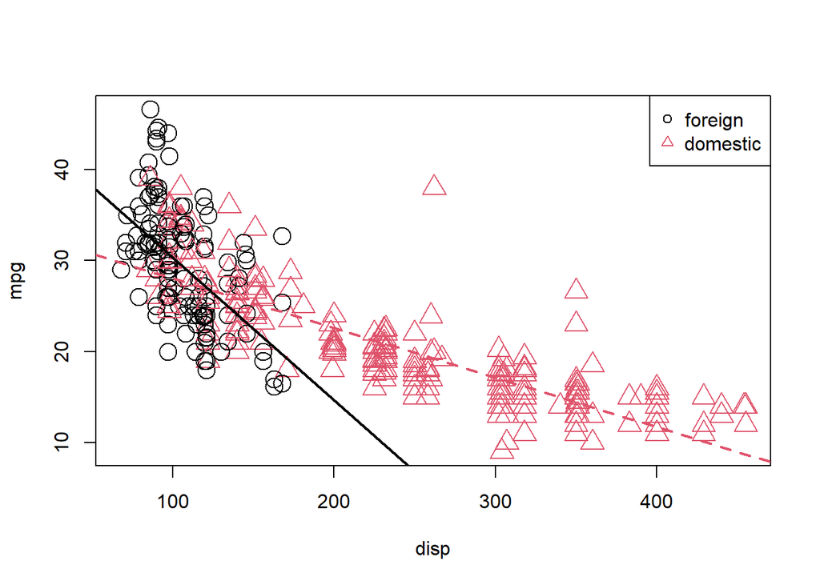

```r
int_foreign <- mpg_disp_int$coef[1]
int_domestic <- mpg_disp_int$coef[1] + mpg_disp_int$coef[3]

slope_foreign <- mpg_disp_int$coef[2]
slope_domestic <- mpg_disp_int$coef[2] + mpg_disp_int$coef[4]

plot(mpg ~ disp, data = autompg,
     col = domestic + 1,
     pch = domestic + 1,
     cex = 2)
abline(int_foreign, slope_foreign, col = 1, lty = 1, lwd = 2)
abline(int_domestic, slope_domestic, col = 2, lty = 2, lwd = 2)
legend("topright", c("foreign", "domestic"),
       col = c(1, 2), pch = c(1, 2))
```

# Numeric-numeric interaction

$$Y = \beta_0 + \beta_1x_1 + \beta_2x_2 + \beta_3x_1x_2 + \epsilon$$
where

- $Y$ is `mpg`
- $x_1$ is `disp`
- $x_2$ is `hp`

Now the slope of $x_1$ is affected by $x_2$ and the opposite is true as well.

$$Y = \beta_0 + (\beta_1 + \beta_3x_2)x_1 + \beta_2x_2 + \epsilon$$
$$Y = \beta_0 + \beta_1x_1 + (\beta_2 + \beta_3x_1)x_2 + \epsilon$$

Let’s fit the additive and the interactive models

```r
(mpg_disp_add_hp <- lm(mpg ~ disp + hp, data = autompg))
```

```
##
## Call:
## lm(formula = mpg ~ disp + hp, data = autompg)
##
## Coefficients:
## (Intercept)         disp           hp
##     37.2232      -0.0459      -0.0458
```

```r
(mpg_disp_int_hp <- lm(mpg ~ disp * hp, data = autompg))
```

```
##
## Call:
## lm(formula = mpg ~ disp * hp, data = autompg)
##
## Coefficients:
## (Intercept)         disp           hp      disp:hp
##   52.408200    -0.100174    -0.219820     0.000566
```

```r
summary(mpg_disp_int_hp)
```

```
##
## Call:
## lm(formula = mpg ~ disp * hp, data = autompg)
##
## Residuals:
##    Min     1Q Median     3Q    Max
## -10.79  -2.31  -0.57   2.14  17.92
##
## Coefficients:
##               Estimate Std. Error t value Pr(>|t|)
## (Intercept) 52.4081998  1.5227267    34.4   <2e-16 ***
## disp        -0.1001738  0.0066382   -15.1   <2e-16 ***
## hp          -0.2198200  0.0198694   -11.1   <2e-16 ***
## disp:hp      0.0005658  0.0000516    11.0   <2e-16 ***
## ---
## Signif. codes:  0 '***' 0.001 '**' 0.01 '*' 0.05 '.' 0.1 ' ' 1
##
## Residual standard error: 3.9 on 379 degrees of freedom
## Multiple R-squared:  0.755,  Adjusted R-squared:  0.753
## F-statistic:  390 on 3 and 379 DF,  p-value: <2e-16
```

Is the $x_1$ $x_2$ interaction relevant?

$$H_0: \beta_3 = 0$$

# Cylinder example

```r
is.factor(autompg$cyl)
```

```
## [1] TRUE
```

```r
levels(autompg$cyl)
```

```
## [1] "4" "6" "8"
```

$$v_1 =
\begin{cases}
1 & \text{4 cylinder} \\
0 & \text{not 4 cylinder}
\end{cases}$$
$$v_2 =
\begin{cases}
1 & \text{6 cylinder} \\
0 & \text{not 6 cylinder}
\end{cases}$$
$$v_3 =
\begin{cases}
1 & \text{8 cylinder} \\
0 & \text{not 8 cylinder}
\end{cases}$$

```r
(mpg_disp_add_cyl <- lm(mpg ~ disp + cyl, data = autompg))
```

```
##
## Call:
## lm(formula = mpg ~ disp + cyl, data = autompg)
##
## Coefficients:
## (Intercept)         disp         cyl6         cyl8
##     34.9993      -0.0522      -3.6332      -2.0360
```

$$Y = \beta_0 + \beta_1x_1 + \beta_2v_2 + \beta_3v_3 + \epsilon,$$

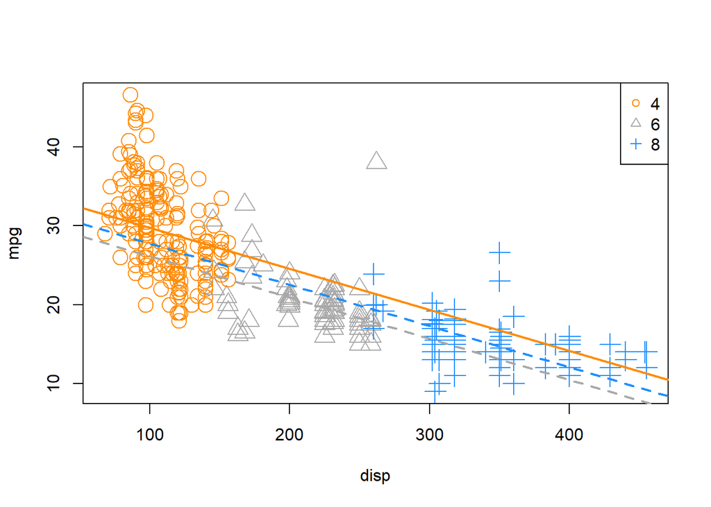

```r
# Reference level it's when v_1 = 4
int_4cyl <- mpg_disp_add_cyl$coef[1]
# Reference level + beta_3 is the intercept for 6 cyl
int_6cyl <- mpg_disp_add_cyl$coef[1] + mpg_disp_add_cyl$coef[3]
# Reference level + beta_4 is the intercept for 8 cyl
int_8cyl <- mpg_disp_add_cyl$coef[1] + mpg_disp_add_cyl$coef[4]

slope <- mpg_disp_add_cyl$coef[2]

plot_colors <- c("Darkorange", "darkgrey", "dodgerblue")

plot(mpg ~ disp, data = autompg,
     col = plot_colors[cyl],
     pch = as.numeric(cyl),
     cex = 2)
abline(int_4cyl, slope, col = plot_colors[1], lty = 1, lwd = 2)
abline(int_6cyl, slope, col = plot_colors[2], lty = 2, lwd = 2)
abline(int_8cyl, slope, col = plot_colors[3], lty = 2, lwd = 2)

legend("topright", levels(autompg$cyl),
       col = plot_colors, pch = c(1, 2, 3))
```

For a model where each line has a different slope we need:

$$Y = \beta_0 + \beta_1x + \beta_2v_2 + \beta_3v_3 + \gamma_2xv_2 + \gamma_3xv_3 + \epsilon,$$

```r
(mpg_disp_int_cyl <- lm(mpg ~ disp * cyl, data = autompg))
```

```
##
## Call:
## lm(formula = mpg ~ disp * cyl, data = autompg)
##
## Coefficients:
## (Intercept)         disp         cyl6         cyl8    disp:cyl6    disp:cyl8
##      43.591       -0.131      -13.200      -20.857        0.083        0.108
```

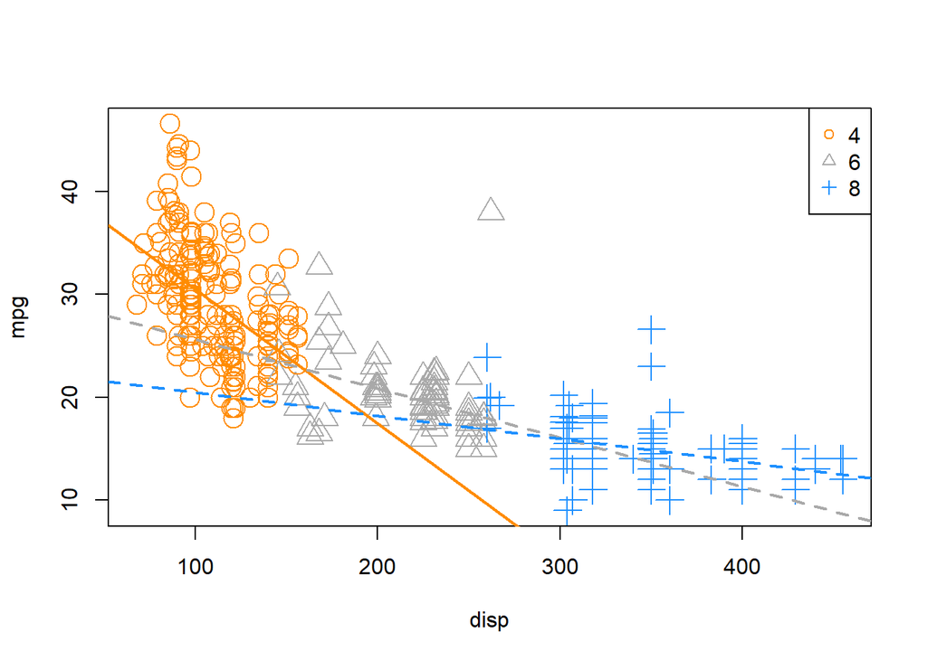

```r
# Reference level it's when v_1 = 4
int_int_4cyl <- mpg_disp_int_cyl$coef[1]
# Reference level + beta_3 is the intercept for 6 cyl
int_int_6cyl <- mpg_disp_int_cyl$coef[1] + mpg_disp_int_cyl$coef[3]
# Reference level + beta_4 is the intercept for 8 cyl
int_int_8cyl <- mpg_disp_int_cyl$coef[1] + mpg_disp_int_cyl$coef[4]

slope_4cyl <- mpg_disp_int_cyl$coef[2]
slope_6cyl <- mpg_disp_int_cyl$coef[2] + mpg_disp_int_cyl$coef[5]
slope_8cyl <- mpg_disp_int_cyl$coef[2] + mpg_disp_int_cyl$coef[6]

plot_colors <- c("Darkorange", "darkgrey", "dodgerblue")

plot(mpg ~ disp, data = autompg,
     col = plot_colors[cyl],
     pch = as.numeric(cyl),
     cex = 2)
abline(int_int_4cyl, slope_4cyl, col = plot_colors[1], lty = 1, lwd = 2)
abline(int_int_6cyl, slope_6cyl, col = plot_colors[2], lty = 2, lwd = 2)
abline(int_int_8cyl, slope_8cyl, col = plot_colors[3], lty = 2, lwd = 2)

legend("topright", levels(autompg$cyl),
       col = plot_colors, pch = c(1, 2, 3))
```

Is having different slopes significant?

$$H_0: \gamma_2 = \gamma_3 = 0$$
Since we are testing for 2 parameters, we need an anova test.

```r
anova(mpg_disp_add_cyl, mpg_disp_int_cyl)
```

```
## Analysis of Variance Table
##
## Model 1: mpg ~ disp + cyl
## Model 2: mpg ~ disp * cyl
##   Res.Df  RSS Df Sum of Sq    F  Pr(>F)
## 1    379 7300
## 2    377 6552  2       748 21.5 1.4e-09 ***
## ---
## Signif. codes:  0 '***' 0.001 '**' 0.01 '*' 0.05 '.' 0.1 ' ' 1
```

# Parameterization

Instead of having reference levels for the slope and intercept. We can have separate:

$$Y = \mu_1v_1 + \mu_2v_2 + \mu_3v_3 + \beta_1xv_1 + \beta_2xv_2 + \beta_3xv_3 + \epsilon$$

```r
# both slope and intercept with reference level
lm(mpg ~ disp * cyl, data = autompg)
```

```
##
## Call:
## lm(formula = mpg ~ disp * cyl, data = autompg)
##
## Coefficients:
## (Intercept)         disp         cyl6         cyl8    disp:cyl6    disp:cyl8
##      43.591       -0.131      -13.200      -20.857        0.083        0.108
```

```r
# both are independent, no reference level
lm(mpg ~ 0 + cyl + disp:cyl, data = autompg)
```

```
##
## Call:
## lm(formula = mpg ~ 0 + cyl + disp:cyl, data = autompg)
##
## Coefficients:
##      cyl4       cyl6       cyl8  cyl4:disp  cyl6:disp  cyl8:disp
##   43.5905    30.3903    22.7335    -0.1307    -0.0477    -0.0225
```

```r
# Intercepts are independent, but slopes have reference levels
lm(mpg ~ 0 + cyl * disp, data = autompg)
```

```
##
## Call:
## lm(formula = mpg ~ 0 + cyl * disp, data = autompg)
##
## Coefficients:
##      cyl4       cyl6       cyl8       disp  cyl6:disp  cyl8:disp
##    43.591     30.390     22.733     -0.131      0.083      0.108
```

```r
lm(mpg ~ 0 + cyl + disp + disp:cyl, data = autompg)
```

```
##
## Call:
## lm(formula = mpg ~ 0 + cyl + disp + disp:cyl, data = autompg)
##
## Coefficients:
##      cyl4       cyl6       cyl8       disp  cyl6:disp  cyl8:disp
##    43.591     30.390     22.733     -0.131      0.083      0.108
```

# Larger models

$$Y = \beta_0 + \beta_1x_1 + \beta_2x_2 + \beta_3x_3 + \beta_4x_1x_2 + \beta_5x_1x_3 + \beta_6x_2x_3 + \beta_7x_1x_2x_3 + \epsilon,$$

```r
(big_model <- lm(mpg ~ disp * hp * domestic, data = autompg))
```

```
##
## Call:
## lm(formula = mpg ~ disp * hp * domestic, data = autompg)
##
## Coefficients:
##      (Intercept)              disp                hp          domestic
##        60.645784         -0.141587         -0.354472        -12.571888
##          disp:hp     disp:domestic       hp:domestic  disp:hp:domestic
##         0.001369          0.049330          0.185153         -0.000916
```

```r
# This one also gives us all possible interactions
#(big_model <- lm(mpg ~ (disp + hp + domestic) ^ 3, data = autompg))
```

Is the 3 way interaction significant?

$$H_0: \beta_7 = 0$$

```r
(two_way_int_mod <- lm(mpg ~ disp * hp + disp * domestic + hp * domestic, data = autompg))
```

```
##
## Call:
## lm(formula = mpg ~ disp * hp + disp * domestic + hp * domestic,
##     data = autompg)
##
## Coefficients:
##   (Intercept)           disp             hp       domestic        disp:hp
##     52.042243      -0.062652      -0.251872      -3.614455       0.000464
## disp:domestic    hp:domestic
##     -0.030510       0.078428
```

```r
# Below means I want all possible 2 way interactions
# two_way_int_mod <- lm(mpg ~ (disp + hp + domestic) ^ 3, data = autompg))
```

```r
anova(two_way_int_mod, big_model)
```

```
## Analysis of Variance Table
##
## Model 1: mpg ~ disp * hp + disp * domestic + hp * domestic
## Model 2: mpg ~ disp * hp * domestic
##   Res.Df  RSS Df Sum of Sq    F Pr(>F)
## 1    376 5673
## 2    375 5646  1      27.6 1.83   0.18
```

```r
summary(big_model)
```

```
##
## Call:
## lm(formula = mpg ~ disp * hp * domestic, data = autompg)
##
## Residuals:
##     Min      1Q  Median      3Q     Max
## -11.941  -2.215  -0.401   1.943  18.409
##
## Coefficients:
##                    Estimate Std. Error t value Pr(>|t|)
## (Intercept)       60.645784   6.600085    9.19  < 2e-16 ***
## disp              -0.141587   0.063440   -2.23    0.026 *
## hp                -0.354472   0.081226   -4.36 0.000017 ***
## domestic         -12.571888   7.064351   -1.78    0.076 .
## disp:hp            0.001369   0.000673    2.03    0.043 *
## disp:domestic      0.049330   0.064005    0.77    0.441
## hp:domestic        0.185153   0.087088    2.13    0.034 *
## disp:hp:domestic  -0.000916   0.000677   -1.35    0.177
## ---
## Signif. codes:  0 '***' 0.001 '**' 0.01 '*' 0.05 '.' 0.1 ' ' 1
##
## Residual standard error: 3.88 on 375 degrees of freedom
## Multiple R-squared:  0.76,   Adjusted R-squared:  0.756
## F-statistic:  170 on 7 and 375 DF,  p-value: <2e-16
```

The big model has a smaller mean squared errors but is not significant

```r
mean(resid(big_model) ^ 2)
```

```
## [1] 14.74
```

```r
mean(resid(two_way_int_mod) ^ 2)
```

```
## [1] 14.81
```

Are the 2 way interactions significant?

$$H_0: \beta_4 = \beta_5 = \beta_6 = 0$$

```r
(additive_mode <- lm(mpg ~ disp + hp + domestic, data = autompg))
```

```
##
## Call:
## lm(formula = mpg ~ disp + hp + domestic, data = autompg)
##
## Coefficients:
## (Intercept)         disp           hp     domestic
##     37.8553      -0.0349      -0.0595      -2.1152
```

```r
anova(additive_mode, two_way_int_mod)
```

```
## Analysis of Variance Table
##
## Model 1: mpg ~ disp + hp + domestic
## Model 2: mpg ~ disp * hp + disp * domestic + hp * domestic
##   Res.Df  RSS Df Sum of Sq    F Pr(>F)
## 1    379 7370
## 2    376 5673  3      1696 37.5 <2e-16 ***
## ---
## Signif. codes:  0 '***' 0.001 '**' 0.01 '*' 0.05 '.' 0.1 ' ' 1
```